# Practical Machine Learning Week 4 Project

Younghoon Seo

5/5/2021

# Overview

Using devices such as Jawbone Up, Nike FuelBand, and Fitbit it is now possible to collect a large amount of data about personal activity relatively inexpensively. These type of devices are part of the quantified self movement – a group of enthusiasts who take measurements about themselves regularly to improve their health, to find patterns in their behavior, or because they are tech geeks. One thing that people regularly do is quantify how much of a particular activity they do, but they rarely quantify how well they do it.

In this project, we will utilize data from accelerometers on the belt, forearm, arm, and dumbell of 6 participants. They were asked to perform barbell lifts correctly and incorrectly in 5 different ways. More information is available from the website here: http://web.archive.org/web/20161224072740/http:/groupware.les.inf.puc-rio.br/har (see the section on the Weight Lifting Exercise Dataset).

# Data and Library Loading

```r
library(ggplot2)
library(caret)
library(rattle)
library(corrplot)
library(randomForest)
set.seed(12345)
```

```r
train_url<-"https://d396qusza40orc.cloudfront.net/predmachlearn/pml-training.csv"
test_url<- "https://d396qusza40orc.cloudfront.net/predmachlearn/pml-testing.csv"

if (!file.exists("./data")) {
        dir.create("./data")
}
if (!file.exists("./data/pml-training.csv")) {
        download.file(train_url, destfile="./data/pml-training.csv", method="curl")
}
if (!file.exists("./data/pml-testing.csv")) {
        download.file(test_url, destfile="./data/pml-testing.csv", method="curl")
}
```

```r
traincsv <- read.csv("./data/pml-training.csv")
testcsv <- read.csv("./data/pml-testing.csv")
```

# Cleaning and Processing Data

Missing values and metadata (first seven variables/columns) were eliminated from the data.

```r
traincsv<-traincsv[,colSums(is.na(traincsv))==0]
traincsv <- traincsv[,-c(1:7)]
```

Afterward, near zero variance variables were also removed

```r
nvz<-nearZeroVar(traincsv)
traincsv<-traincsv[,-nvz]
```

Upon eliminating unnecessary variables, traincsv data was split into training and validation data sets.

```r
inTrain<-createDataPartition(y=traincsv$classe,p=.7,list=F)
train_data<-traincsv[inTrain,]
validation_data<-traincsv[-inTrain,]
```

The process of data cleaning was also applied to the test data set.

```r
testcsv<-testcsv[,colSums(is.na(testcsv))==0]
testcsv <- testcsv[,-c(1:7)]
traincsv<-traincsv[,-nvz]
test_data<-testcsv
```

Prior to creating the models, a correlation matrix of variables in the training data set was created for visualizing the relationship between the variables.

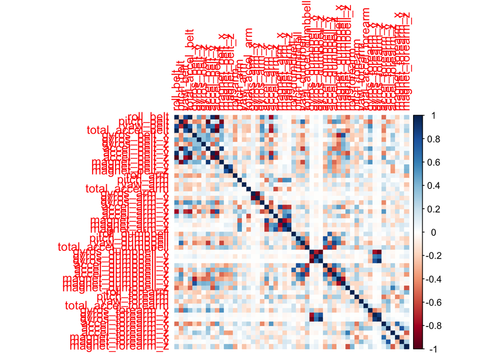

```r
cor_data<-cor(train_data[,-length(names(train_data))])
corrplot(cor_data,method="color")
```

# Models

This investigation utilized the following models:

- Decision Tree
- Random Forest
- Gradient Boosted Trees

## Decision Tree

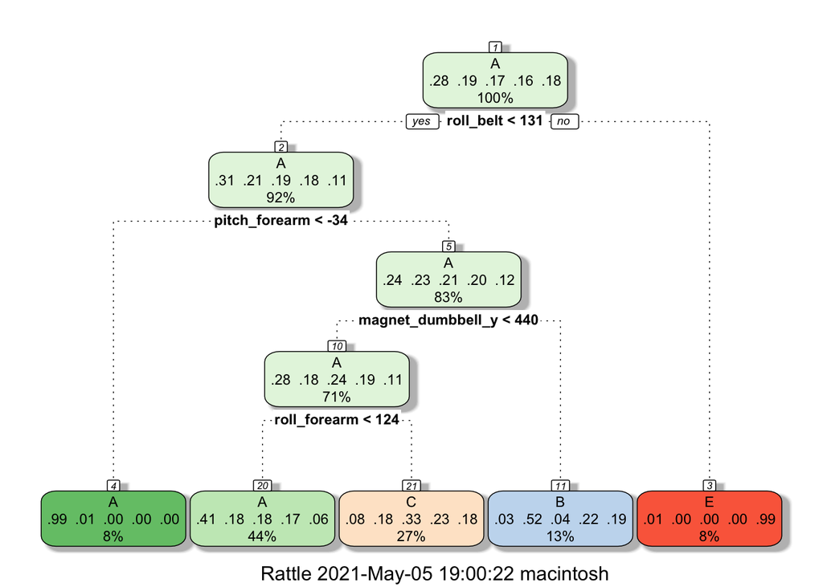

```r
model_tree<-train(classe~.,data=train_data,method="rpart",
                  trControl=trainControl(method="cv",number=4,verboseIter=F))
fancyRpartPlot(model_tree$finalModel)
```

```r
predict_tree<-predict(model_tree,validation_data)
confusionMatrix(predict_tree,factor(validation_data$classe))
```

```
## Confusion Matrix and Statistics
##
##           Reference
## Prediction    A    B    C    D    E
##          A 1525  484  499  423  153
##          B   29  385   37  187  159
##          C  116  270  490  354  289
##          D    0    0    0    0    0
##          E    4    0    0    0  481
##
## Overall Statistics
##
##                Accuracy : 0.4895
##                  95% CI : (0.4767, 0.5024)
##     No Information Rate : 0.2845
##     P-Value [Acc > NIR] : < 2.2e-16
##
##                   Kappa : 0.3324
##
##  Mcnemar's Test P-Value : NA
##
## Statistics by Class:
##
##                      Class: A Class: B Class: C Class: D Class: E
## Sensitivity            0.9110  0.33802  0.47758   0.0000  0.44455
## Specificity            0.6298  0.91319  0.78823   1.0000  0.99917
## Pos Pred Value         0.4945  0.48306  0.32258      NaN  0.99175
## Neg Pred Value         0.9468  0.85181  0.87723   0.8362  0.88870
## Prevalence             0.2845  0.19354  0.17434   0.1638  0.18386
## Detection Rate         0.2591  0.06542  0.08326   0.0000  0.08173
## Detection Prevalence   0.5240  0.13543  0.25811   0.0000  0.08241
## Balanced Accuracy      0.7704  0.62560  0.63291   0.5000  0.72186
```

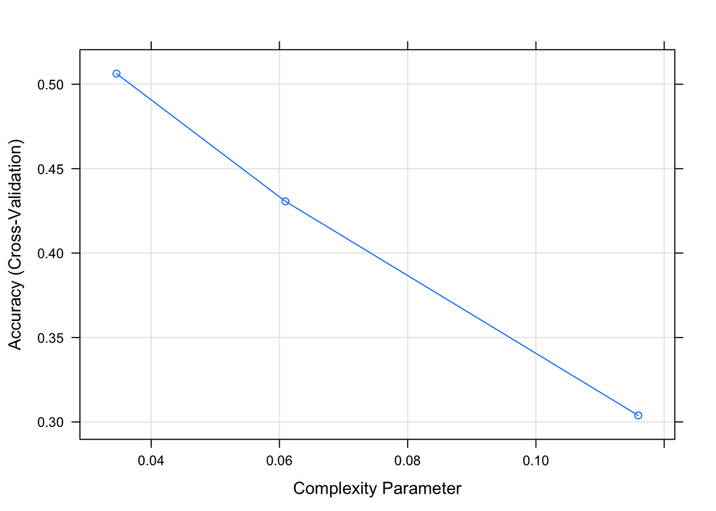

```r
plot(model_tree)
```

```r
accuracy_tree<-postResample(predict_tree,factor(validation_data$classe))["Accuracy"]
oose_tree<-1-accuracy_tree
```

## Random Forest

```r
model_forest<-train(classe~.,data=train_data,method="rf",
                    trControl=trainControl(method="cv",number=4,verboseIter=F))
```

```r
predict_forest<-predict(model_forest,validation_data)
confusionMatrix(predict_forest,factor(validation_data$classe))
```

```
## Confusion Matrix and Statistics
##
##           Reference
## Prediction    A    B    C    D    E
##          A 1672    6    0    0    0
##          B    1 1130    5    0    0
##          C    1    3 1018    7    2
##          D    0    0    3  956    1
##          E    0    0    0    1 1079
##
## Overall Statistics
##
##                Accuracy : 0.9949
##                  95% CI : (0.9927, 0.9966)
##     No Information Rate : 0.2845
##     P-Value [Acc > NIR] : < 2.2e-16
##
##                   Kappa : 0.9936
##
##  Mcnemar's Test P-Value : NA
##
## Statistics by Class:
##
##                      Class: A Class: B Class: C Class: D Class: E
## Sensitivity            0.9988   0.9921   0.9922   0.9917   0.9972
## Specificity            0.9986   0.9987   0.9973   0.9992   0.9998
## Pos Pred Value         0.9964   0.9947   0.9874   0.9958   0.9991
## Neg Pred Value         0.9995   0.9981   0.9984   0.9984   0.9994
## Prevalence             0.2845   0.1935   0.1743   0.1638   0.1839
## Detection Rate         0.2841   0.1920   0.1730   0.1624   0.1833
## Detection Prevalence   0.2851   0.1930   0.1752   0.1631   0.1835
## Balanced Accuracy      0.9987   0.9954   0.9948   0.9954   0.9985
```

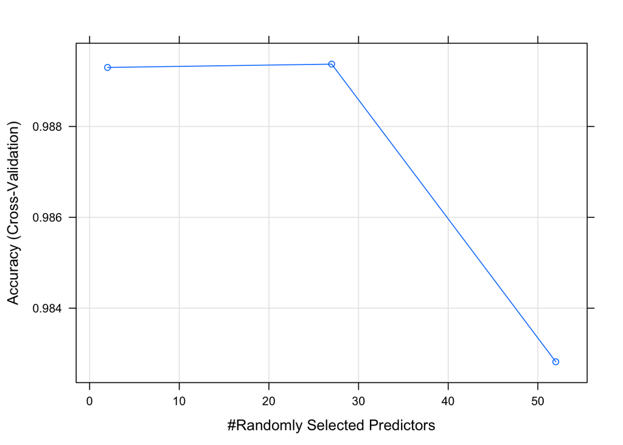

```r
plot(model_forest)
```

```r
accuracy_forest<-postResample(predict_forest,factor(validation_data$classe))["Accuracy"]
oose_forest<-1-accuracy_forest
```

## Gradient Boosted Tree

```r
model_boosting<-train(classe~.,data=train_data,method="gbm",
                      trControl=trainControl(method="cv",number=4,verboseIter=F),verbose=F)
```

```r
predict_boosting<-predict(model_boosting,validation_data)
confusionMatrix(predict_boosting,factor(validation_data$classe))
```

```
## Confusion Matrix and Statistics
##
##           Reference
## Prediction    A    B    C    D    E
##          A 1648   45    0    3    1
##          B   20 1060   35    2   15
##          C    3   31  978   35    8
##          D    3    1   12  920    8
##          E    0    2    1    4 1050
##
## Overall Statistics
##
##                Accuracy : 0.9611
##                  95% CI : (0.9558, 0.9659)
##     No Information Rate : 0.2845
##     P-Value [Acc > NIR] : < 2.2e-16
##
##                   Kappa : 0.9508
##
##  Mcnemar's Test P-Value : 7.007e-06
##
## Statistics by Class:
##
##                      Class: A Class: B Class: C Class: D Class: E
## Sensitivity            0.9845   0.9306   0.9532   0.9544   0.9704
## Specificity            0.9884   0.9848   0.9842   0.9951   0.9985
## Pos Pred Value         0.9711   0.9364   0.9270   0.9746   0.9934
## Neg Pred Value         0.9938   0.9834   0.9901   0.9911   0.9934
## Prevalence             0.2845   0.1935   0.1743   0.1638   0.1839
## Detection Rate         0.2800   0.1801   0.1662   0.1563   0.1784
## Detection Prevalence   0.2884   0.1924   0.1793   0.1604   0.1796
## Balanced Accuracy      0.9864   0.9577   0.9687   0.9747   0.9845
```

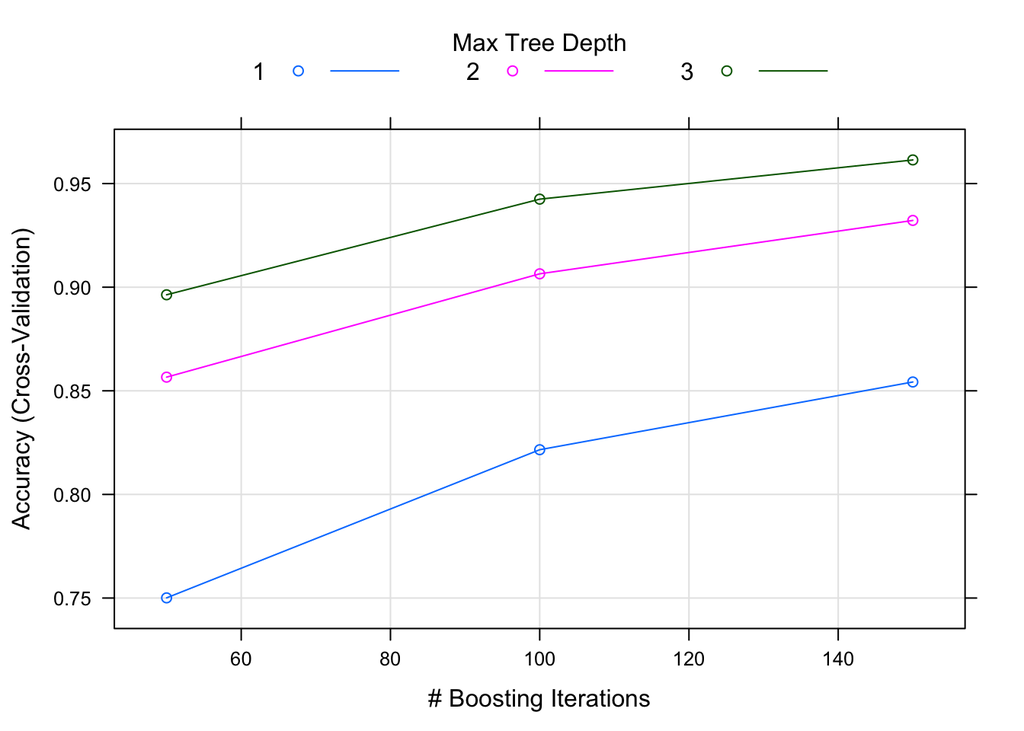

```r
plot(model_boosting)
```

```r
accuracy_boosting<-postResample(predict_boosting,factor(validation_data$classe))["Accuracy"]
oose_boosting<-1-accuracy_boosting
```

# Error Comparison

```r
error_tree<-data.frame(accuracy_tree,oose_tree)
error_forest<-data.frame(accuracy_forest,oose_forest)
error_boosting<-data.frame(accuracy_boosting,oose_boosting)
error_table<-data.frame(Accuracy=c(error_tree[[1]],error_forest[[1]],error_boosting[[1]]),
           Out_Of_Sample_Error=c(error_tree[[2]],error_forest[[2]],error_boosting[[2]]))
rownames(error_table)<-c("Decision Tree","Random Forest","Gradient Boosted Tree")
error_table
```

```
##                        Accuracy Out_Of_Sample_Error
## Decision Tree         0.4895497         0.510450297
## Random Forest         0.9949023         0.005097706
## Gradient Boosted Tree 0.9610875         0.038912489
```

# Prediction

The Random Forest model was used to predict the classe outcome for 20 cases in the test data set.

```r
prediction<-predict(model_forest,test_data)
prediction
```

```
##  [1] B A B A A E D B A A B C B A E E A B B B
## Levels: A B C D E
```